GeoStat Lab · M10 · Previsione e progetto statistico

M10_N01 · Futura

# Fissare l’origine della previsione

5 blocchi R eseguiti1 grafico0 errori · 0 avvisiOffline · MathML

Codice, output e figure dello stesso svolgimento. Ogni notebook riparte dai dati locali ed è autonomo rispetto agli altri.

# La domanda

Quali osservazioni erano disponibili nel dicembre 1998?

## Obiettivi

- Controllare il calendario mensile.
- Separare adattamento e test prima delle scelte.
- Associare origine, bersaglio e orizzonte.

**Prima di iniziare.** Sono richiesti vettori, tabelle e funzioni R di base. I blocchi vanno eseguiti in ordine. Il notebook è autonomo rispetto agli altri.

**Dati e unità.** CO₂ storica: 204 mesi da gennaio 1985 a dicembre 2001, concentrazione in ppm. Le medie derivano dalle osservazioni settimanali attribuite al mese della data, secondo la convenzione del corso. Sono dati storici, distinti da una serie mensile ufficiale e da una misura attuale. Il protocollo usa 168 mesi per l’adattamento (1985–1998) e 36 per il test (1999–2001).

## Preparazione

Aprire il progetto autonomo di Futura o quello generale del corso. I calcoli usano R base e stats. Gli output del notebook vanno in `Risultati/M10_N01/`; i CSV originali restano invariati.

Codice R · preparazione

```r
# Trova la cartella M10 dal progetto autonomo o dal progetto generale.
.gs_cerca <- normalizePath(getwd(),winslash="/",mustWork=TRUE)
repeat {
  .gs_candidati <- c(.gs_cerca,
    file.path(.gs_cerca,"M10_Futura"),
    file.path(.gs_cerca,"03_Notebook_svolti","M10_Futura"),
    file.path(.gs_cerca,"M10","03_Notebook_svolti","M10_Futura"))
  .gs_ok <- file.exists(file.path(.gs_candidati,"M10_N01.Rmd")) &
    file.exists(file.path(.gs_candidati,"R","funzioni_notebook.R"))
  if(any(.gs_ok)) { .gs_modulo <- .gs_candidati[which(.gs_ok)[1L]]; break }
  .gs_padre <- dirname(.gs_cerca)
  if(.gs_padre==.gs_cerca) stop("Aprire il progetto M10_Futura o quello generale dei notebook.")
  .gs_cerca <- .gs_padre
}
source(file.path(.gs_modulo,"R","funzioni_notebook.R"),local=TRUE)
.gs_funzioni <- .gs_prepara_notebook(.gs_modulo,"M10_N01")
carica_dati <- .gs_funzioni$carica_dati
percorso_risultati <- .gs_funzioni$percorso_risultati
options(width=88,digits=6)
if(requireNamespace("knitr",quietly=TRUE)) {
  knitr::opts_chunk$set(echo=TRUE,error=FALSE,warning=TRUE,message=TRUE,
    fig.width=8,fig.height=5,dpi=150,fig.align="center")
}
set.seed(10001)
```

## 1. Il calendario identifica le osservazioni

Una riga corrisponde a un mese. Il controllo usa le date, perché una sequenza di numeri senza calendario non determina l’orizzonte.

Codice R · passo_01

```r
d <- carica_dati("co2_1985_2001.csv")
d$data <- as.Date(d$data)
stopifnot(!anyDuplicated(d$data), !anyNA(d$co2_ppm))
stopifnot(identical(d$data,seq(as.Date("1985-01-01"),as.Date("2001-12-01"),by="month")))
data.frame(prima=min(d$data),ultima=max(d$data),mesi=nrow(d),
           minimo_settimane=min(d$n_settimane))
```

Output eseguito

```
       prima     ultima mesi minimo_settimane
1 1985-01-01 2001-12-01  204                4
```

**Lettura del risultato.** Le 204 righe formano una griglia mensile completa. La copertura settimanale rimane una colonna del dato, anche quando il valore mensile è disponibile.

## 2. La divisione conserva l’ordine

L’origine fissa è l’ultimo mese del train. Tutti i valori successivi servono soltanto alla verifica del protocollo già definito.

Codice R · passo_02

```r
c2 <- prepara_co2(carica_dati("co2_1985_2001.csv"))
train <- c2$train; test <- c2$test; h <- c2$h
 data.frame(insieme=c("Train","Test"),n=c(length(train),length(test)),
   inizio=c("1985-01","1999-01"),fine=c("1998-12","2001-12"))
 stopifnot(length(train)==168L,h==36L,max(time(train))<min(time(test)))
```

Output eseguito

```
  insieme   n  inizio    fine
1   Train 168 1985-01 1998-12
2    Test  36 1999-01 2001-12
```

**Lettura del risultato.** Nessuna osservazione 1999–2001 entra nel train. Il periodo di test è noto come calendario, mentre i suoi valori restano fuori dalla stima.

## 3. L’orizzonte misura la distanza dall’origine

La separazione appare sul grafico. L’esposizione del test qui rende visibile il disegno didattico: le scelte di modello devono essere fissate prima del suo uso per confrontare gli errori.

Codice R · passo_03

```r
stile_grafico()
plot(c2$dati$data,c2$dati$co2_ppm,type="n",xlab="Data",ylab="CO2 (ppm)",
     main="Train e test: origine dicembre 1998")
lines(c2$dati$data[1:168],c2$dati$co2_ppm[1:168],col=palette_geo[1],lwd=2)
lines(c2$date_test,as.numeric(test),col=palette_geo[2],lwd=2)
abline(v=as.numeric(as.Date("1999-01-01")),lty=2)
legend("topleft",c("Train: 168 mesi","Test: 36 mesi"),col=palette_geo[1:2],lty=1,bty="n")
data.frame(origine="1998-12",bersaglio=as.character(c2$date_test[c(1,12,36)]),h=c(1,12,36))
```

Output eseguito

```
  origine  bersaglio  h
1 1998-12 1999-01-01  1
2 1998-12 1999-12-01 12
3 1998-12 2001-12-01 36
```

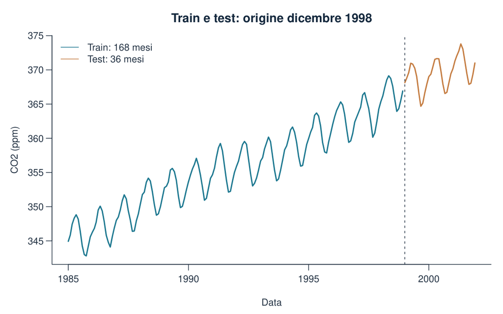

Figura 1 · Output del blocco `passo_03`. PDF vettoriale.

**Lettura del risultato.** I primi 12 mesi e il terzo anno del test rispondono a orizzonti diversi. Conservarli evita di chiamare «previsione a un mese» una sequenza prodotta una sola volta per 36 mesi.

## Variante svolta

**Un’origine precedente.** Spostare l’origine a dicembre 1997 e misurare quante osservazioni restano nei due segmenti.

Codice R · variante

```r
tr97 <- window(c2$y,end=c(1997,12)); te97 <- window(c2$y,start=c(1998,1))
data.frame(origine="1997-12",n_train=length(tr97),n_test=length(te97))
stopifnot(length(tr97)+length(te97)==204L)
```

Output eseguito

```
  origine n_train n_test
1 1997-12     156     48
```

La variante cambia il problema: aumenta il periodo da prevedere e riduce quello disponibile per l’adattamento. Non confrontare i suoi errori come se il protocollo fosse identico.

## Errore da riconoscere

Rimescolare le righe prima dello split, oppure scegliere la data di separazione dopo aver confrontato gli errori sul futuro.

## Risposta alla domanda

Al dicembre 1998 sono disponibili i 168 mesi del train. Una previsione verificabile conserva la data dell’origine, le date bersaglio e il numero di passi. I risultati su questo archivio storico hanno valore didattico.

## Riferimento nel corso

Questo svolgimento sviluppa il laboratorio `M10_N01` di [GeoStat Lab M10](https://marzione00.github.io/Lab_Geo/#indice). Il [codice originale del laboratorio](https://github.com/marzione00/Lab_Geo/blob/649f7cc577b96bd1044d81e78a2f530813e4f96b/materiali/laboratori/M10/M10_N01.R) è conservato anche in `R/Originali_corso`. Gli ampliamenti e le varianti sono identificati nella mappa allegata.

Documentazione dei metodi: [R stats, arima](https://stat.ethz.ch/R-manual/R-devel/library/stats/html/arima.html), [predict.Arima](https://stat.ethz.ch/R-manual/R-devel/library/stats/html/predict.arima.html), [Box.test](https://stat.ethz.ch/R-manual/R-devel/library/stats/html/box.test.html) e [p.adjust](https://stat.ethz.ch/R-manual/R-devel/library/stats/html/p.adjust.html).